# 공동 조사 RTK측량 지점 대상

샘플수와 간격에 대한 건의

전청옥 서울대학교 지리학과

2022-04-28

본 문서는 5월 공동 현장 조사를 위한 계획을 위해 작성되었습니다.

수문 모델링에 필요한 고도자료 샘플링 계획입니다.

임의로 여러 계획을 제안드립니다. 구체적인 해상도나 고도자료 수집 위치에 대해서 의견 부탁드립니다.

# 1 분석 준비

```
[1] "C:/Users/lophital/Documents/damsand"
```

2021년 항공 사진을 살펴보고 봄 여름 시기에 식생으로 뒤덮히지 않았던 지역을 크게 3곳 선택하였습니다.

```r
st_read("research.gpkg") -> ra
```

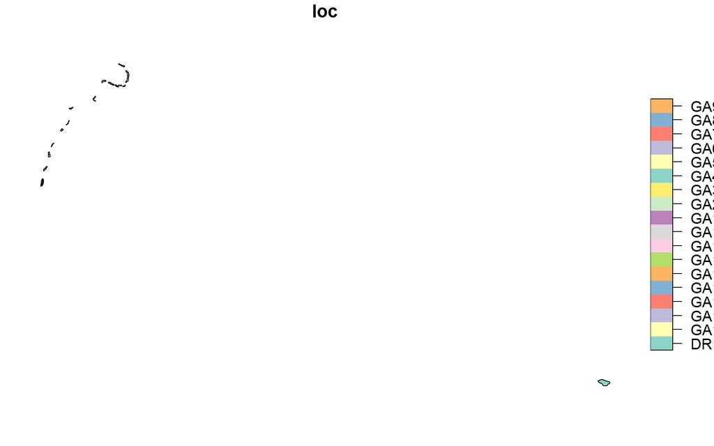

```r
plot(ra)
```

도리섬 1곳과 경안천 일대의 2곳을 선정하였습니다.

```r
ra %>%
dplyr::filter(loc == "DR1") -> DR1

ra %>%
dplyr::filter(loc == "GA1") -> GA1

ra %>%
dplyr::filter(loc == "GA2") -> GA2
```

좌측 상단 아주 작게 경안천 사이트 2곳, 우측 하단에 도리섬을 보여드립니다. 이외에도 자갈 사주로 보이는 곳을 선정했지만 RTK 측정을 위해 임의로 2개만 설정해 본 문서에서 제시해드립니다. 추가적인 지역은 문서 최하단에 모두 시각화 하였습니다.

경안천 지역 2곳은 연구 지역내 자갈이나 모래가 있을 것으로 보이는 지점을 다음 스트리트뷰와 연동하여 찾아본 것입니다. 21년 스트리트뷰로 살펴본 결과 인공위성 영상으론 모래인 지역들이 대부분 식생으로 가득찬 것을 볼 수 있었습니다. 그나마 자갈밭이 나타나는 지점으로 경안천에서 2곳을 선정하였습니다. 도리섬은 매년 경계가 자주 바뀌는 관계로 식생이 자리잡은 지점을 대상으로 샘플링 폴리곤을 지정했습니다.

```r
sf::st_sample(DR1, 100, type="regular", by_polygon = T) %>% st_set_crs(4326) -> sample_DR1
sf::st_sample(GA1, 100, type="regular", by_polygon = T) %>% st_set_crs(4326) -> sample_GA1
sf::st_sample(GA2, 100, type="regular", by_polygon = T) %>% st_set_crs(4326) -> sample_GA2
sf::st_sample(DR1, 50, type="regular", by_polygon = T) %>% st_set_crs(4326) -> sample_DR1.50
sf::st_sample(GA1, 50, type="regular", by_polygon = T) %>% st_set_crs(4326) -> sample_GA1.50
sf::st_sample(GA2, 50, type="regular", by_polygon = T) %>% st_set_crs(4326) -> sample_GA2.50
```

주변 지형과 판별이 쉽도록 인터렉티브한 지도를 준비했습니다.

```r
tmap::tmap_mode("view")
```

# 2 샘플링 시각화

## 2.1 도리섬(DR1)

다음은 50개의 샘플을 도리섬에 표시한 지도입니다.

```r
tm_shape(DR1, unit = "m") +
  tm_polygons(alpha = 0.2) +
tm_shape(sample_DR1.50, unit = "m") +
  tm_dots() +
tm_basemap("Esri.WorldImagery") +
tm_basemap("OpenStreetMap.Mapnik") +
  tm_scale_bar()
```

[interactive chart not shown]

샘플 간의 간격은 62.3M 입니다.

```r
st_distance(sample_DR1.50)[1,2]
```

```
62.3 [m]
```

다음은 약 98개의 샘플지점을 표시한 지도입니다.

```r
tm_shape(DR1, unit = "m") +
    tm_polygons(alpha = 0.2) +
tm_shape(sample_DR1, unit = "m") +
  tm_dots() +
tm_basemap("Esri.WorldImagery") +
  tm_basemap("OpenStreetMap.Mapnik") +
  tm_scale_bar()
```

[interactive chart not shown]

샘플 간의 간격은 44m입니다.

```r
st_distance(sample_DR1)[1,2]
```

```
44 [m]
```

```r
sf::st_sample(DR1, 1000, type="regular", by_polygon = T) %>% st_set_crs(4326) -> sample_DR1.1000
```

다음은 13.9m 간격으로 1000여개의 RTK지점을 표시한것입니다.

```r
tm_shape(DR1, unit = "m") +
tm_basemap("Esri.WorldImagery") +
  tm_basemap("OpenStreetMap.Mapnik") +
    tm_polygons(alpha = 0.2) +
tm_shape(sample_DR1.1000, unit = "m") +
  tm_dots() +
tm_scale_bar()
```

[interactive chart not shown]

```r
st_distance(sample_DR1.1000)[1,2]
```

```
13.9 [m]
```

## 2.2 경안천 1 지점(GA1)

```r
tm_shape(GA1, unit = "m") +
tm_basemap("Esri.WorldImagery") +
  tm_basemap("OpenStreetMap.Mapnik") +
    tm_polygons(alpha = 0.2) +
tm_shape(sample_GA1.50, unit = "m") +
  tm_dots() +
tm_scale_bar()
```

[interactive chart not shown]

```r
st_distance(sample_GA1.50)[1,2]
```

```
25.3 [m]
```

다음은 경안천 1구역 샘플 100개의 지도입니다. 샘플간 간격은 17.9m입니다.

```r
tm_shape(GA1, unit = "m") +
tm_basemap("Esri.WorldImagery") +
  tm_basemap("OpenStreetMap.Mapnik") +
    tm_polygons(alpha = 0.2) +
tm_shape(sample_GA1, unit = "m") +
  tm_dots() +
tm_scale_bar()
```

[interactive chart not shown]

```r
st_distance(sample_GA1)[1,2]
```

```
17.9 [m]
```

## 2.3 경안천 2 지점(GA2)

다음은 경안천 2구역 샘플 50개의 지도입니다. 샘플간 간격 약 17.6미터 입니다.

```r
tm_shape(GA2, unit = "m") +
tm_basemap("Esri.WorldImagery") +
  tm_basemap("OpenStreetMap.Mapnik") +
    tm_polygons(alpha = 0.2) +
tm_shape(sample_GA2.50, unit = "m") +
  tm_dots()
```

[interactive chart not shown]

```r
st_distance(sample_GA2.50)[1,2]
```

```
17.6 [m]
```

다음은 경안천 2구역 샘플 100개의 지도입니다. 샘플간 간격은 12.4m 입니다.

```r
tm_shape(GA2, unit = "m") +
tm_basemap("Esri.WorldImagery") +
  tm_basemap("OpenStreetMap.Mapnik") +
    tm_polygons(alpha = 0.2) +
tm_shape(sample_GA2, unit = "m") +
  tm_dots() +
tm_scale_bar()
```

[interactive chart not shown]

```r
st_distance(sample_GA2)[1,2]
```

```
12.4 [m]
```

## 2.4 경안천 기타 지점(GA3~17)

경안천 기타 지점들은 항공영상 상에서는 자갈사주와 유사해 보이나 면적이 작거나 스트리트뷰 상에서 초본으로 뒤덮여 보이는 지역들입니다.

```r
# 50pcs
map(c(3:17), function(i){
ra %>%
dplyr::filter(loc == paste0("GA",i))}) %>%
map(., function(GA){
  tm_shape(GA, unit = "m") +
tm_basemap("Esri.WorldImagery") +
    tm_basemap("OpenStreetMap.Mapnik") +
    tm_polygons(alpha = 0.2) +
tm_shape(sf::st_sample(GA, 50, type="regular", by_polygon = T) %>% st_set_crs(4326) , unit = "m") +
  tm_dots() +
tm_scale_bar()}) -> tm_GAs.50

map(c(3:17), function(i){
ra %>%
dplyr::filter(loc == paste0("GA",i))}) %>%
map(function(GA){
st_distance(sf::st_sample(GA, 50, type="regular", by_polygon = T) %>% st_set_crs(4326))[1,2]}) -> tm_GAs.D.50

# 100pcs
map(c(3:17), function(i){
ra %>%
dplyr::filter(loc == paste0("GA",i))}) %>%
map(., function(GA){
  tm_shape(GA, unit = "m") +
tm_basemap("Esri.WorldImagery") +
    tm_basemap("OpenStreetMap.Mapnik") +
    tm_polygons(alpha = 0.2) +
tm_shape(sf::st_sample(GA, 100, type="regular", by_polygon = T) %>% st_set_crs(4326) , unit = "m") +
  tm_dots() +
tm_scale_bar()}) -> tm_GAs.100

map(c(3:17), function(i){
ra %>%
dplyr::filter(loc == paste0("GA",i))}) %>%
map(function(GA){
st_distance(sf::st_sample(GA, 100, type="regular", by_polygon = T) %>% st_set_crs(4326))[1,2]}) -> tm_GAs.D.100
```

GA3 지점-50개

```r
tm_GAs.50[[1]]
```

[interactive chart not shown]

```r
tm_GAs.D.50[[1]]
```

```
22.1 [m]
```

GA3 지점-100개

```r
tm_GAs.100[[1]]
```

[interactive chart not shown]

```r
tm_GAs.D.100[[1]]
```

```
15.6 [m]
```

GA4 지점-50개

```r
tm_GAs.50[[2]]
```

[interactive chart not shown]

```r
tm_GAs.D.50[[2]]
```

```
25.2 [m]
```

GA4 지점-100개

```r
tm_GAs.100[[2]]
```

[interactive chart not shown]

```r
tm_GAs.D.100[[2]]
```

```
17.8 [m]
```

GA5 지점-50개

```r
tm_GAs.50[[3]]
```

[interactive chart not shown]

```r
tm_GAs.D.50[[3]]
```

```
27.2 [m]
```

GA5 지점-100개

```r
tm_GAs.100[[3]]
```

[interactive chart not shown]

```r
tm_GAs.D.100[[3]]
```

```
19.3 [m]
```

GA6 지점-50개

```r
tm_GAs.50[[4]]
```

[interactive chart not shown]

```r
tm_GAs.D.50[[4]]
```

```
15.8 [m]
```

GA6 지점-100개

```r
tm_GAs.100[[4]]
```

[interactive chart not shown]

```r
tm_GAs.D.100[[4]]
```

```
14 [m]
```

GA7 지점-50개

```r
tm_GAs.50[[5]]
```

[interactive chart not shown]

```r
tm_GAs.D.50[[5]]
```

```
11.9 [m]
```

GA7 지점-100개

```r
tm_GAs.100[[5]]
```

[interactive chart not shown]

```r
tm_GAs.D.100[[5]]
```

```
8.4 [m]
```

GA8 지점 -50개

```r
tm_GAs.50[[6]]
```

[interactive chart not shown]

```r
tm_GAs.D.50[[6]]
```

```
18.3 [m]
```

GA8 지점 -100개

```r
tm_GAs.100[[6]]
```

[interactive chart not shown]

```r
tm_GAs.D.100[[6]]
```

```
66.6 [m]
```

GA9 지점-50개

```r
tm_GAs.50[[7]]
```

[interactive chart not shown]

```r
tm_GAs.D.50[[7]]
```

```
22.9 [m]
```

GA9 지점-100개

```r
tm_GAs.100[[7]]
```

[interactive chart not shown]

```r
tm_GAs.D.100[[7]]
```

```
16.2 [m]
```

GA10 지점-50개

```r
tm_GAs.50[[8]]
```

[interactive chart not shown]

```r
tm_GAs.D.50[[8]]
```

```
34.1 [m]
```

GA10 지점-100개

```r
tm_GAs.100[[8]]
```

[interactive chart not shown]

```r
tm_GAs.D.100[[8]]
```

```
10.2 [m]
```

GA11 지점-50개

```r
tm_GAs.50[[9]]
```

[interactive chart not shown]

```r
tm_GAs.D.50[[9]]
```

```
14 [m]
```

GA11 지점-100개

```r
tm_GAs.100[[9]]
```

[interactive chart not shown]

```r
tm_GAs.D.100[[9]]
```

```
9.89 [m]
```

GA12 지점-50개

```r
tm_GAs.50[[10]]
```

[interactive chart not shown]

```r
tm_GAs.D.50[[10]]
```

```
17.6 [m]
```

GA12 지점-100개

```r
tm_GAs.100[[10]]
```

[interactive chart not shown]

```r
tm_GAs.D.100[[10]]
```

```
40.5 [m]
```

GA13 지점-50개

```r
tm_GAs.50[[11]]
```

[interactive chart not shown]

```r
tm_GAs.D.50[[11]]
```

```
13.7 [m]
```

GA13 지점-100개

```r
tm_GAs.100[[11]]
```

[interactive chart not shown]

```r
tm_GAs.D.100[[11]]
```

```
15.6 [m]
```

GA14 지점-50개

```r
tm_GAs.50[[12]]
```

[interactive chart not shown]

```r
tm_GAs.D.50[[12]]
```

```
23.3 [m]
```

GA14 지점-100개

```r
tm_GAs.100[[12]]
```

[interactive chart not shown]

```r
tm_GAs.D.100[[12]]
```

```
16.6 [m]
```

GA15 지점-50개

```r
tm_GAs.50[[13]]
```

[interactive chart not shown]

```r
tm_GAs.D.50[[13]]
```

```
26 [m]
```

GA15 지점-100개

```r
tm_GAs.100[[13]]
```

[interactive chart not shown]

```r
tm_GAs.D.100[[13]]
```

```
18.4 [m]
```

GA16 지점-50개

```r
tm_GAs.50[[14]]
```

[interactive chart not shown]

```r
tm_GAs.D.50[[14]]
```

```
21.8 [m]
```

GA16 지점-100개

```r
tm_GAs.100[[14]]
```

[interactive chart not shown]

```r
tm_GAs.D.100[[14]]
```

```
24.7 [m]
```

GA17 지점-50개

```r
tm_GAs.50[[15]]
```

[interactive chart not shown]

```r
tm_GAs.D.50[[15]]
```

```
25.6 [m]
```

GA17 지점-100개

```r
tm_GAs.100[[15]]
```

[interactive chart not shown]

```r
tm_GAs.D.100[[15]]
```

```
18.1 [m]
```